# Forest Health Citizen Science Community

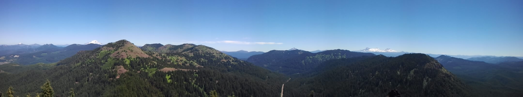

## Welcome

Welcome to the webpage for the *Forest Health Citizen Science Community*. The sole purpose of this page is to share information relevant to the community by the community.

## Announcements

### Join us in Stolkholm, June 2024!

Abstract submissions are open for the [XXVI IUFRO World Congress](https://iufro2024.com/) in Stolkholm, Sweden. The deadline to submit abstracts is June 2, 2023.

- Please consider submitting an abstract for the below session.
  - **Public engagement to keep urban trees and communities healthy**
    - ID: 50013
    - Session type: Technical (oral and poster presentations welcome)
    - Congress theme: 4: Forests for sustainable societies

> *Have an additional announcement? Feel free to share it with the community (ForestHealthCitSci@groups.io), update this R Markdown document in the [Github Repository](https://github.com/jmhulbert/fhcs), or email ForestHealthCitSci@gmail.com.*

## Join the Community

Anyone working in the space between forest health and society is welcome to join.

### Mailing List

Subscribe to the [mailing-list](https://groups.io/g/foresthealthcitsci) by visiting the [Groups.io page (https://groups.io/g/ForestHealthCitSci)](https://groups.io/g/ForestHealthCitSci) or by emailing the subscribe email listed below:

- Group Email Addresses
  - Post: ForestHealthCitSci@groups.io
  - Subscribe: ForestHealthCitSci+subscribe@groups.io
  - Unsubscribe: ForestHealthCitSci+unsubscribe@groups.io
  - Group Owner: ForestHealthCitSci+owner@groups.io
  - Help: ForestHealthCitSci+help@groups.io

Note that you do *not* need a groups.io account to subscribe.

### Slack Workspace

You can join our [Slack Workspace](https://foresthealthcitsci.slack.com) at this [link](https://join.slack.com/t/foresthealthcitsci/shared_invite/enQtODU4ODE2MjA5Mzc4LTRjOTc4YzdlNzUwOTk1MDVjMjdhYmFhNTU4NWI2MTk1NWFhM2UzY2M1OThhOGVjYzBiMGRkZjNjYjg1NjVlNzQ).

Note that you need a Slack account to join the Slack Community.

### Github Repository

This webpage and the project list below are hosted in a [github repository](https://github.com/jmhulbert/fhcs).

Anyone is welcome to collaborate to add or make changes to the [github repository (https://github.com/jmhulbert/fhcs)](https://github.com/jmhulbert/fhcs). The content on this page is compiled using R Markdown, but the project list is maintained as a [.csv file](https://github.com/jmhulbert/fhcs/blob/7abe537b37548a2aa3f0cffe2a85c6763f559be1/files/data/ProjectList.csv).

Note that you need a github account to collaborate or make changes. Feel free to contact ForestHealthCitSci@gmail.com for additional details or instructions.

- As a repository collaborator:
  - You are welcome to clone the repository to your system and work from the R Project (*fhcs.Rproj*) file in Rstudio or you can make changes to the *ProjectList.csv* file.
  - You can also make changes directly to the .csv file through your browser.
  - Or you can make changes by downloading the .csv file, altering, committing and pushing it back to the repository.

*Note that the Markdown (index.Rmd) file will need to be knit before the changes will be visible on this webpage.*

### Tree Health Citizen Science Network (UK)

Practitioners of tree health focused citizen science projects in the UK are encouraged to also join the [UK Tree Health Citizen Science Network](https://www.observatree.org.uk/about/uk-tree-health-citizen-science-network-2/).

You can also join the conversation on twitter with the hashtag: #treecitsci

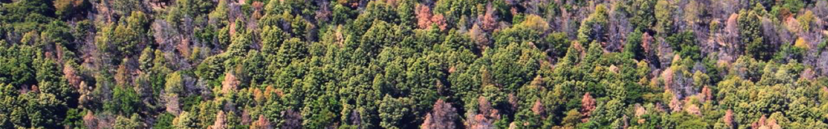

## List of Forest Health Citizen Science Projects

> **Have a project to add to this list?** *Share it with the community (ForestHealthCitSci@groups.io), add it to the [.csv file](https://github.com/jmhulbert/fhcs/blob/7abe537b37548a2aa3f0cffe2a85c6763f559be1/files/data/ProjectList.csv), or email the details to ForestHealthCitSci@gmail.com.*

The projects below are listed alphabetically. There are currently 29 projects listed below. Email ForestHealthCitSci@gmail.com for corrections.

| Project | Country | Sector | Institution.Organization | Forest.health.field | Forest.environment | Forest.health.issue | Website |
| --- | --- | --- | --- | --- | --- | --- | --- |
| Arrest the Pest | USA, Minnesota | Government | Minnesota Department of Agriculture | Invasive plants, plant pests and diseases | Urban and natural forests | Multiple | https://www.mda.state.mn.us/plants-insects/arrest-pest |
| Backyard Bark Beetles | USA | Public | University of Florida | Plant pests | Urban and natural forests | Bark and ambrosia beetles | http://www.backyardbarkbeetles.org/ |
| Budworm Tracker | Canada, Quebec | Government | Canadian Forest Service and Healthy Forest Partnership | Plant pests | Urban and natural forests | Spruce budworm | https://budwormtracker.ca/#/ |
| Cape Citizen Science | South Africa | Public | University of Pretoria | Plant disease | Natural forests | Phytophthora spp. | https://citsci.co.za |
| Conker Tree Science | United Kingdom | Public | Newcastle University, Natural Environment Research Council | Plant pests | Urban and natural forests | The horse-chestnut leaf-miner | http://www.conkertreescience.org.uk/ |
| Early Detection Citizen Science | USA, Oregon | Public | Oregon State University | Plant disease | Natural forests | Sudden oak death | http://wrdc.usu.edu/files-ou/Kline-Oak-Death-RCSPR19.pdf |
| Find-A-Pest | New Zealand | Private | Scion | Plant pests and weeds | Urban forests, natural forests, plantations | Multiple | http://www.findapest.nz/ |
| First Detector Program | USA | Public | National Plant Diagnostic Network, Cornell University | Plant pests and diseases | Urban and natural forests | Multiple | https://www.firstdetector.org/ |
| Forest Health Watch | USA, Washington | Public | Washington State University | Plant pests and Diseases | Urban and natural forests | Multiple | https://foresthealth.org/ |
| Forest Pest First Detector | USA, Minnesota | Public | University of Minnesota | Plant pests and diseases | Urban and natural forests | Multiple | https://extension.umn.edu/natural-resources-volunteers/forest-pest-first-detector |
| Healthy Trees Healthy Cities | USA | Multiple | University of Georgia, USDA Forest Service, and The Nature Conservancy | Abiotic factors, plant pests and plant diseases | Urban forests | Multiple | https://healthytreeshealthycitiesapp.org/ |
| Kauri Rescue | New Zealand | Non-profit | Kauri Rescue | Plant disease | Urban and natural forests | Kauri dieback disease (Phytophthora agathidicida) | http://www.kaurirescue.org.nz/ |
| LIFE ARTEMIS | Slovenia | Government | Slovenian Forestry Institute | Invasive plant pests and diseases | Urban and natural forests | Multiple | https://www.invazivke.si/ |
| Nature’s Notebook | USA | Public | University of Arizona/USA National Phenology Network | Plant and animal phenology, timing of treatment, restoration | Urban and natural forests |  | https://www.usanpn.org/natures_notebook |
| Oak bodyguards | France | Public | INRA | Plant pests and climate change | Urban and natural forests | Background herbivory, exotic pests | https://sites.google.com/view/oakbodyguards/home |
| Observatree | United Kingdom | Government | Forest Research | Plant pests and diseases | Urban and natural forests | Multiple | https://www.observatree.org.uk |
| OPAL Tree Health Survey | United Kingdom | Public | Imperial College London | Plant pests and Diseases | Urban and natural forests | Multiple | https://www.imperial.ac.uk/opal/surveys/treehealthsurvey/ |
| Oregon Forest Pest Detectors | USA, Oregon | Public | Oregon State University | Plant pests | Urban and natural forests | Multiple | https://workspace.oregonstate.edu/course/Oregon-Forest-Pest-Detector?hsLang=en |
| P-FOR INIA | Uruguay | Private | National Institute of Agricultural Research | Plant pests and diseases | Plantations | Multiple | http://inia.uy/estaciones-experimentales/direcciones-regionales/inia-tacuaremb%C3%B3/nueva-herramienta-en-sanidad-forestal-p-for-inia |
| Pest Scene Investigators | USA, Oregon | Public | Oregon State University | Plant pests and diseases | Private forests | Multiple | https://catalog.extension.oregonstate.edu/em9161/html |
| Phytophthora Citizen Science | Sweden | Public | Swedish University for Agricultural Sciences | Plant disease | Urban and natural forests | Phytophthora dieback | https://phytophthora.se/ |
| Phytophthora Stream Monitoring Program | USA, Washington | Public | Washington State University | Plant disease | Urban and natural forests | Phytophthora spp. | https://ppo.puyallup.wsu.edu/sod/monitoring/streams/ |
| Save the Ash “Radda asken” | Sweden | Public | Swedish University of Agricultural Sciences | Forest Pathology | Forests, Urban areas | Ash dieback | https://www.slu.se/ew-nyheter/2019/5/hjalp-till-att-radda-asken/ |
| Silvalert | France | Non-profit | PLURIFOR consortium | Forest tree damages | Urban and natural forests | Biotic and abiotic agents | http://www.silvalert.net |
| SOD Blitz | USA, California | Public | UC Berkeley | Plant disease | Urban and natural forests | Sudden oak death | https://nature.berkeley.edu/garbelottowp/?page_id=148 |
| TreeAlert | United Kingdom | Government | Forest Research | Plant pests and diseases | Urban and natural forests | Multiple | https://www.forestresearch.gov.uk/tools-and-resources/tree-alert/ |
| TreeSnap | USA | Public | University of Tennessee and University of Kentucky | Tree resistance to plant pests and disesaes | Urban and natural forests | Multiple | https://treesnap.org/ |
| Utah First Detectors Program | USA, Utah | Public | Utah State University | Plant pests | Urban and natural forests | Multiple | http://utahpests.usu.edu/caps/get-involved |
| Vigil’Ink | France | Multiple | National Institute of Agronomic Research and University of Bordeaux | Plant disease | Urban and natural forests | Chestnut ink disease | http://ephytia.inra.fr/fr/P/157/Vigil_encre |

You can cite this table as: Hulbert J, Barton M, Castagneyrol B, Oraizo C, Rosemartin A. 2023. “Forest Health Citizen Science Project List” FHCS. Commit ID:929469, https://github.com/jmhulbert/fhcs. Updated: February 25, 2023, [DOI:10.5281/zenodo.3572753](https://zenodo.org/record/3572753).

Currently the individuals who shared projects in the Google form are listed as authors. Anyone is welcome to add to the project list or be included in the citation. Collaborators in the [github repository](https://github.com/jmhulbert/fhcs) will also be added to the citation.

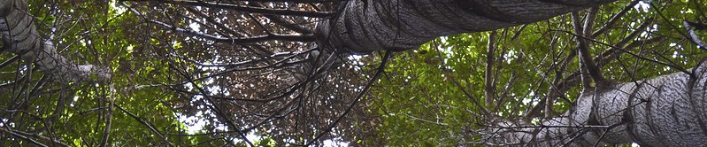

## Community Publications

> **Have publications or articles to share here?** *Share them with the community (ForestHealthCitSci@groups.io), add them to the [Github Repository](https://github.com/jmhulbert/fhcs), or email the details to ForestHealthCitSci@gmail.com.*
- Peer-reviewed publications (listed by publication year)
  - **Your publications here.**
  - Hulbert JM, Hallett RA, Roy HE and Cleary M (2023) [Citizen science can enhance strategies to detect and manage invasive forest pests and pathogens](https://www.frontiersin.org/articles/10.3389/fevo.2023.1113978/full). Front. Ecol. Evol. 11:1113978. doi: 10.3389/fevo.2023.1113978.
  - Gardiner, M. M., & Roy, H. E. (2022). [The role of community science in entomology](https://www.annualreviews.org/doi/abs/10.1146/annurev-ento-072121-075258). Annual review of entomology, 67, 437-456.
  - Probert, A. F., Wegmann, D., Volery, L., Adriaens, T., Bakiu, R., Bertolino, S., … & Bacher, S. (2022). [Identifying, reducing, and communicating uncertainty in community science: a focus on alien species](https://link.springer.com/article/10.1007/s10530-022-02858-8). Biological Invasions, 24(11), 3395-3421.
  - Caley P and Barry SC (2022) [The effectiveness of citizen surveillance for detecting exotic vertebrates](https://www.frontiersin.org/articles/10.3389/fevo.2022.1012198/full). Front. Ecol. Evol. 10:1012198. doi: 10.3389/fevo.2022.1012198.
  - de Groot, M., Pocock, M.J.O., Bonte, J. et al. 2023. [Citizen Science and Monitoring Forest Pests: a Beneficial Alliance?](https://link.springer.com/article/10.1007/s40725-022-00176-9#citeas). Curr Forestry Rep 9, 15–32. https://doi.org/10.1007/s40725-022-00176-9.
  - de Groot, M., Ogris, N., van der Meij, M. et al. 2022. [Where to search: the use of opportunistic data for the detection of an invasive forest pest](https://link.springer.com/article/10.1007/s10530-022-02857-9). Biol Invasions 24, 3523–3537. https://doi.org/10.1007/s10530-022-02857-9.
  - Crow P, Perez-Sierra A, Kavčič A, Lewthwaite K, Kolšek M, Ogris N, Piškur B, Kus Veenvliet J, Zidar S, Sancisi-Frey S and de Groot M. 2020. [Using Citizen Science to monitor the spread of tree pests and diseases: outcomes of two projects in Slovenia and the UK](https://www.reabic.net/journals/mbi/2020/4/MBI_2020_Crow_etal.pdf). Management of Biological Invasions 11(4):703-719.
  - Pocock MJO, Marzano M, Bullas-Appleton E, Dyke A, de Groot M, Shuttleworth CM and White R. 2020.[Ethical dilemmas when using citizen science for early detection of invasive tree pests and diseases](https://www.reabic.net/journals/mbi/2020/4/MBI_2020_Pocock_etal.pdf). Management of Biological Invasions 11(4):720-732.
  - Slawson DD, Moffat AJ. 2020. [How Effective Are Citizen Scientists at Contributing to Government Tree Health Public Engagement and Surveillance Needs—An Analysis of the UK Open Air Laboratories (OPAL) Survey Model](https://www.mdpi.com/2075-4450/11/9/550). Insects 11(9):550.
  - Garbelotto M, Popenuck T, Hall B, schweigkofler wolfgang, Dovana F, Goldstein De Salazar R, et al. 2020. [Citizen science uncovers *Phytophthora ramorum* as a threat to several rare or endangered California manzanita species](https://apsjournals.apsnet.org/doi/10.1094/PDIS-03-20-0619-RE). Plant Disease. + Caley, P., M. Welvaert, and S. C. Barry. 2019. [Crowd surveillance: estimating citizen science reporting probabilities for insects of biosecurity concern](https://link.springer.com/article/10.1007%2Fs10340-019-01115-7). *Journal of Pest Science, 1-8*.
  - Crocker, E., B. Condon, A. Almsaeed, B. Jarret, C. D. Nelson, A. G. Abbott, D. Main, and M. Staton. 2019. [TreeSnap: A citizen science app connecting tree enthusiasts and forest scientists](https://nph.onlinelibrary.wiley.com/doi/full/10.1002/ppp3.41). *Plants, People, Planet 0:1–6*.
  - Baker, E., M. J. Jeger, J. D. Mumford, and N. Brown. 2018. [Enhancing plant biosecurity with citizen science monitoring: comparing methodologies using reports of acute oak decline](https://link.springer.com/article/10.1007%2Fs10109-018-0285-2). *Journal of Geographical Systems 21:111–131*.
  - Graziosi I, Townsend L, Rieske LK (2018). [The EAB Discovery Trail: A Novel Approach to Engage the Public in Emerald Ash Borer Research](https://academic.oup.com/ae/article/64/3/190/5098341). *American Entomologist* 64:190–193.
  - Hallet, R. and T. Hallett. 2018. [Citizen science and tree health assessment: how useful are the data](https://www.fs.usda.gov/treesearch/pubs/57408)? *Arboriculture & Urban Forestry. 44(6): 236–247*.
  - Lione, G., P. Gonthier, and M. Garbelotto. 2017. [Environmental factors driving the recovery of bay laurels from *Phytophthora ramorum* infections: an application of numerical ecology to citizen science](https://www.mdpi.com/1999-4907/8/8/293). *Forests 8(8): 293*.
  - Thomas, M. L., N. Gunawardene, K. Horton, A. Williams, S. O’Connor, S. McKirdy, and J. van der Merwe. 2017. [Many eyes on the ground: citizen science is an effective early detection tool for biosecurity](https://link.springer.com/article/10.1007/s10530-017-1481-6). *Biological Invasions 19:2751–2765*.
  - Brown, N., F. van den Bosch, S. Parnell, and S. Denman. 2017. [Integrating regulatory surveys and citizen science to map outbreaks of forest diseases: acute oak decline in England and Wales](https://royalsocietypublishing.org/doi/full/10.1098/rspb.2017.0547). *Proceedings of the Royal Society B: Biological Sciences 284:20170547*.
  - Bates, A. J., P. Lakeman Fraser, L. Robinson, J. C. Tweddle, J. P. Sadler, S. E. West, S. Norman, M. Batson, and L. Davies. 2015. [The OPAL bugs count survey: exploring the effects of urbanisation and habitat characteristics using citizen science](https://link.springer.com/article/10.1007/s11252-015-0470-8). *Urban Ecosystems 18:1477–1497*.
  - Meentemeyer, R. K., M. A. Dorning, J. B. Vogler, D. Schmidt, and M. Garbelotto. 2015. [Citizen science helps predict risk of emerging infectious disease](https://esajournals.onlinelibrary.wiley.com/doi/abs/10.1890/140299). *Frontiers in Ecology and the Environment 13:189–194*.
  - Ingwell, L. L., and E. L. Preisser. 2011. [Using citizen science programs to identify host resistance in pest-invaded forests](https://conbio.onlinelibrary.wiley.com/doi/abs/10.1111/j.1523-1739.2010.01567.x). *Conservation Biology 25:182–188*.
- Online reports (PDFs)
  - **Your reports here.**
  - Gupta, N., and Slawson, D., 2019. Tree Health Citizen Science in the UK: Opportunities, Challenges and Future Roadmap. *Imperial College, London*.
  - Crow, P. 2017. [Observatree Explained: a Layperson’s Report](https://www.observatree.org.uk/wp-content/uploads/2017/10/Final-Laymans-report.pdf). *Forest Research*.
- Popular articles about projects listed above
  - **Your articles here.**
  - Kinver M. 2020. [Citizen science taps into public’s love of trees](https://www.bbc.com/news/science-environment-54106793).
  - Garbelotto M. 2019. [Citizen science making a difference for California](https://www.dailycal.org/2019/10/04/citizen-science-making-a-difference-for-california/).
  - Hulbert J, Roets F. 2017. [Citizen science: how ordinary people can guard Cape Town’s biodiversity](https://theconversation.com/citizen-science-how-ordinary-people-can-guard-cape-towns-biodiversity-87373).